# Assignment 03 Stats

Sumanth Donthula

2022-10-09

Problem 1

1.a)

Yes, a linear relation is being observed in the data by scatter plot.

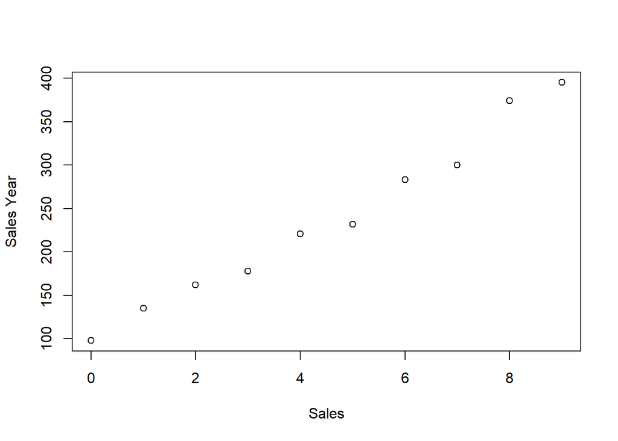

```r
Data=read.table("AS3Q1Data.txt", header = FALSE, sep = "")
Y = Data$V1
X = Data$V2

plot(X,Y,xlab="Sales",ylab="Sales Year")
```

```r
lm1=lm(Y~X)
lm1
```

```
##
## Call:
## lm(formula = Y ~ X)
##
## Coefficients:
## (Intercept)            X
##       91.56        32.50
```

1.b)

By looking at the box cox plot a lambda of 0.5 is suggested. By SSE box cox plot it is evident that SSE is miniumum at lambda=0.5.

```r
resid(lm1)
```

```
##           1           2           3           4           5           6
##   6.4363636  10.9393939   5.4424242 -11.0545455  -0.5515152 -22.0484848
##           7           8           9          10
##  -3.5454545 -19.0424242  22.4606061  10.9636364
```

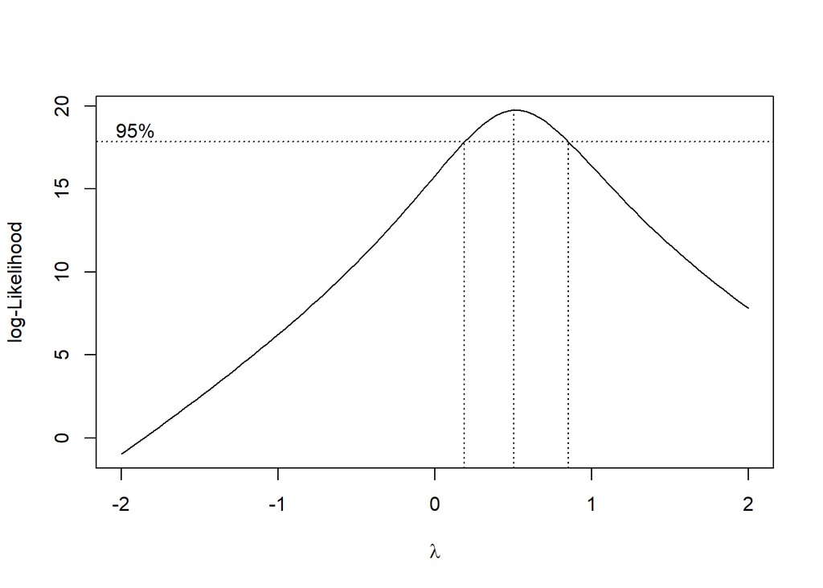

```r
library(MASS)
boxcox(Y~X)
```

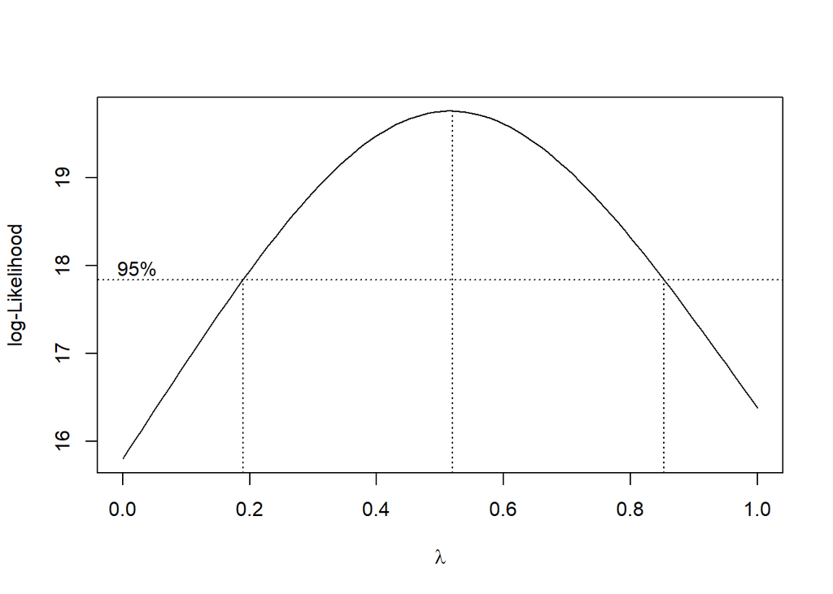

```r
boxcox(Y~X,seq(0,1,0.01))
```

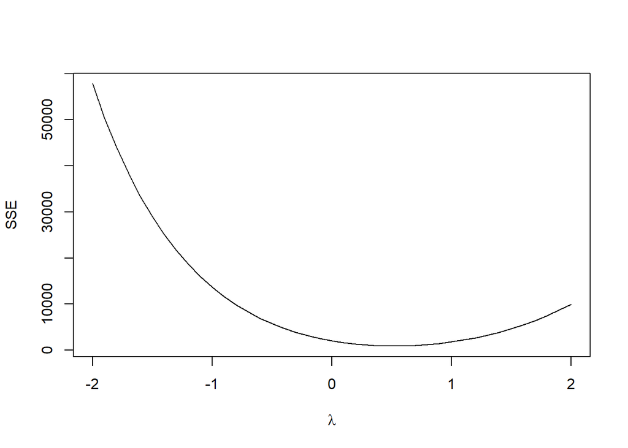

```
##    lambda        SSE
## 1    -2.0 57788.3511
## 2    -1.9 50489.6939
## 3    -1.8 44054.1816
## 4    -1.7 38379.8733
## 5    -1.6 33377.2323
## 6    -1.5 28967.6103
## 7    -1.4 25081.9206
## 8    -1.3 21659.4777
## 9    -1.2 18646.9811
## 10   -1.1 15997.6263
## 11   -1.0 13670.3269
## 12   -0.9 11629.0334
## 13   -0.8  9842.1378
## 14   -0.7  8281.9520
```

[output cut: 27 more lines]

```r
library('ALSM')
boxcox.sse(X,Y)
```

1.c)

The linear relation function is : 10.26093+1.076X

```r
Yroot=Y^0.5
lm2=lm(Yroot~X)
lm2
```

```
##
## Call:
## lm(formula = Yroot ~ X)
##
## Coefficients:
## (Intercept)            X
##      10.261        1.076
```

1.d)

Yes, the linear regression seems a good fit on the transformed data.

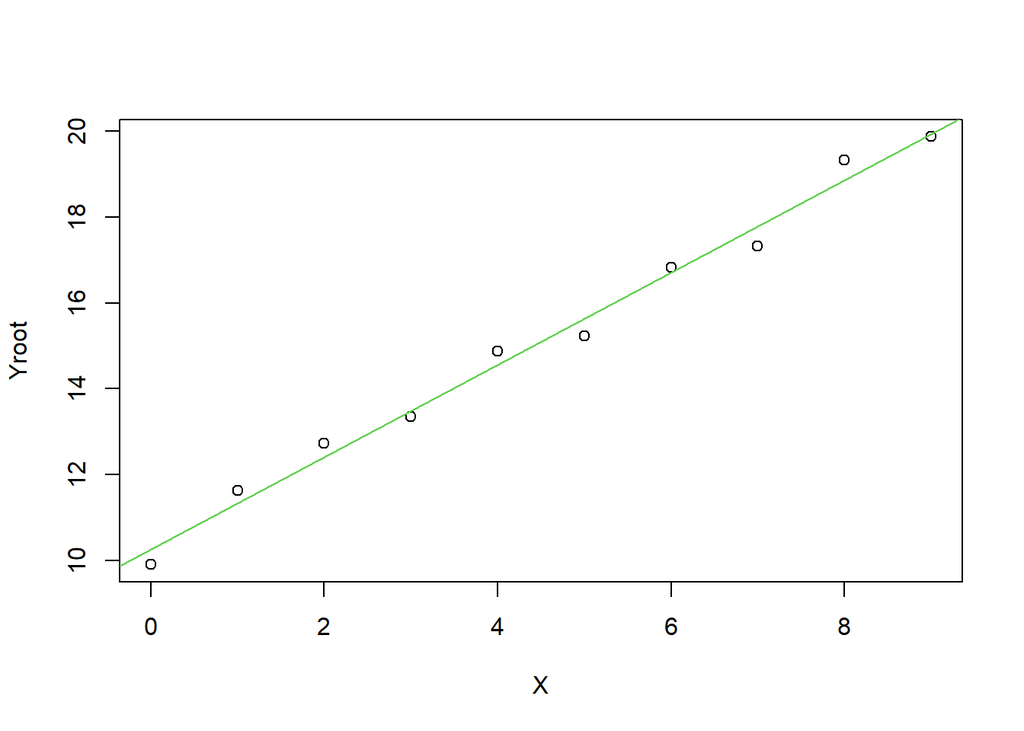

```
## integer(0)
```

```r
plot(X,Yroot)+abline(10.261,1.076,col=3)
```

1.e) Sum of residuals by looking at the residual plot is almost 0 which supports this transformation

From Qq plot, qq line does not line up perfectly but it appears to be in linear relation. So we conclude that residuals are normally distributed.

```r
residual=lm2$residuals
residual
```

```
##           1           2           3           4           5           6
## -0.36143656  0.28172678  0.31440703 -0.14814273  0.29997018 -0.41084412
##           7           8           9          10
##  0.10392174 -0.47446579  0.46781397 -0.07295049
```

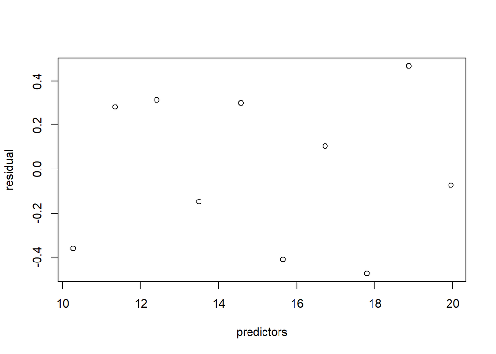

```r
predictors=lm2$fitted.values
plot(predictors,residual)
```

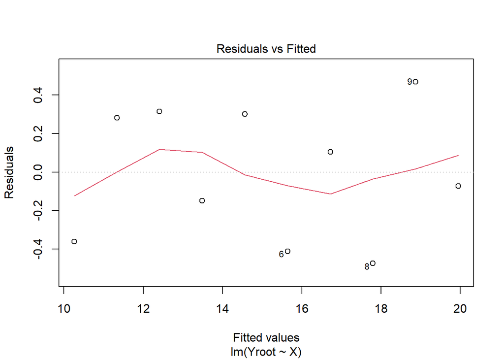

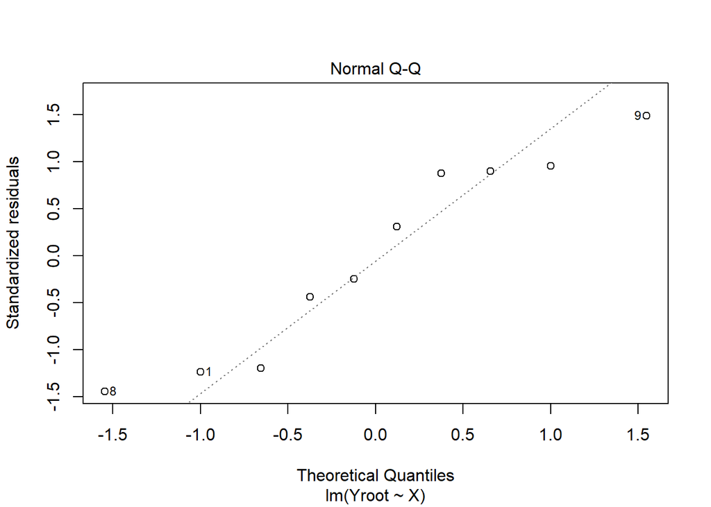

```r
plot(lm2,which=c(1,2))
```

1.f)

The estimated function in original units is:

Ybar=(10.261+1.076X)2

Problem 2:

2.a)

The confidence intervals are

CI45 : 98.6309, 106.9691 CI55 : 88.11124, 93.68876 CI65 : 76.20837, 81.79163

```r
Data2=read.table("AS32Data.txt", header = FALSE, sep = "")
Y = Data2$V1
X = Data2$V2
n=length(X)
Xf =cbind(rep(1,n),X)


Ymat=as.matrix(Y)
Xmat=as.matrix(Xf)


lm=lm(Y~X)
lm
```

```
##
## Call:
## lm(formula = Y ~ X)
##
## Coefficients:
## (Intercept)            X
##      156.35        -1.19
```

```r
anova(lm)
```

```
## Analysis of Variance Table
##
## Response: Y
##           Df  Sum Sq Mean Sq F value    Pr(>F)
## X          1 11627.5 11627.5  174.06 < 2.2e-16 ***
## Residuals 58  3874.4    66.8
## ---
## Signif. codes:  0 '***' 0.001 '**' 0.01 '*' 0.05 '.' 0.1 ' ' 1
```

```r
summary(lm)
```

```
##
## Call:
## lm(formula = Y ~ X)
##
## Residuals:
##      Min       1Q   Median       3Q      Max
## -16.1368  -6.1968  -0.5969   6.7607  23.4731
##
## Coefficients:
##             Estimate Std. Error t value Pr(>|t|)
## (Intercept) 156.3466     5.5123   28.36   <2e-16 ***
## X            -1.1900     0.0902  -13.19   <2e-16 ***
## ---
## Signif. codes:  0 '***' 0.001 '**' 0.01 '*' 0.05 '.' 0.1 ' ' 1
##
## Residual standard error: 8.173 on 58 degrees of freedom
## Multiple R-squared:  0.7501, Adjusted R-squared:  0.7458
## F-statistic: 174.1 on 1 and 58 DF,  p-value: < 2.2e-16
```

```r
sse = sum((fitted(lm) - Y)^2)

Sigmasquare=sse/n-2

#Working hotelling method
X1h=c(1,45)
X2h=c(1,55)
X3h=c(1,65)

Yhat1=156.35-1.19*45
Yhat2=156.35-1.19*55
Yhat3=156.35-1.19*65

measure1=(Sigmasquare*t(X1h)%*%solve(t(Xmat)%*%Xmat)%*%X1h)^0.5

measure2=(Sigmasquare*t(X2h)%*%solve(t(Xmat)%*%Xmat)%*%X2h)^0.5

measure3=(Sigmasquare*t(X3h)%*%solve(t(Xmat)%*%Xmat)%*%X3h)^0.5

W = sqrt(2 * qf(p = 0.95, df1 = 2, df2 = n - 2))
W
```

```
## [1] 2.512342
```

```r
conf1up=Yhat1+W*measure1
conf1lo=Yhat1-W*measure1
conf2up=Yhat2+W*measure2
conf2lo=Yhat2-W*measure2
conf3up=Yhat3+W*measure3
conf3lo=Yhat3-W*measure3

conf45=cbind(conf1lo,conf1up)
conf45
```

```
##         [,1]     [,2]
## [1,] 98.6309 106.9691
```

```r
conf55=cbind(conf2lo,conf2up)
conf55
```

```
##          [,1]     [,2]
## [1,] 88.11124 93.68876
```

```r
conf65=cbind(conf3lo,conf3up)
conf65
```

```
##          [,1]     [,2]
## [1,] 76.20837 81.79163
```

2.b) NO the working hotel model is not the most efficient one as its range is wider compared to normal t distributions confidence interval.

For example here t is 1.67 where as w is 2.51 the band will be larger.

```r
t = qt(0.95,nrow(Data2) - 2)
t
```

```
## [1] 1.671553
```

2.c)

The confidence intervals are

CI48 : 95.62575, 102.8342 CI59 : 83.61339, 88.66661 CI74 : 64.3607, 72.2193

```r
BX1h=c(1,48)
BX2h=c(1,59)
BX3h=c(1,74)

Yhat11=156.35-1.19*48
Yhat21=156.35-1.19*59
Yhat31=156.35-1.19*74


Bmeasure1=(Sigmasquare*t(BX1h)%*%solve(t(Xmat)%*%Xmat)%*%BX1h)^0.5

Bmeasure2=(Sigmasquare*t(BX2h)%*%solve(t(Xmat)%*%Xmat)%*%BX2h)^0.5

Bmeasure3=(Sigmasquare*t(BX3h)%*%solve(t(Xmat)%*%Xmat)%*%BX3h)^0.5

B = qt(1-0.05/(2 * 3), n - 2)

conf11up=Yhat11+B*Bmeasure1
conf11lo=Yhat11-B*Bmeasure1
conf22up=Yhat21+B*Bmeasure2
conf22lo=Yhat21-B*Bmeasure2
conf33up=Yhat31+B*Bmeasure3
conf33lo=Yhat31-B*Bmeasure3
conf48=cbind(conf11lo,conf11up)
conf48
```

```
##          [,1]     [,2]
## [1,] 95.62575 102.8342
```

```r
conf59=cbind(conf22lo,conf22up)
conf59
```

```
##          [,1]     [,2]
## [1,] 83.61339 88.66661
```

```r
conf74=cbind(conf33lo,conf33up)
conf74
```

```
##         [,1]    [,2]
## [1,] 64.3607 72.2193
```

Problem 3

3.a)

The observations from plots provided that there are no outliers and the distribution of each variable is normal.

Correlation matrix shows Y and X1 have significant positive correlation, Y and X2 are positively correlated, but less than Y and X1 and there’s no correlation between X1 and X2.

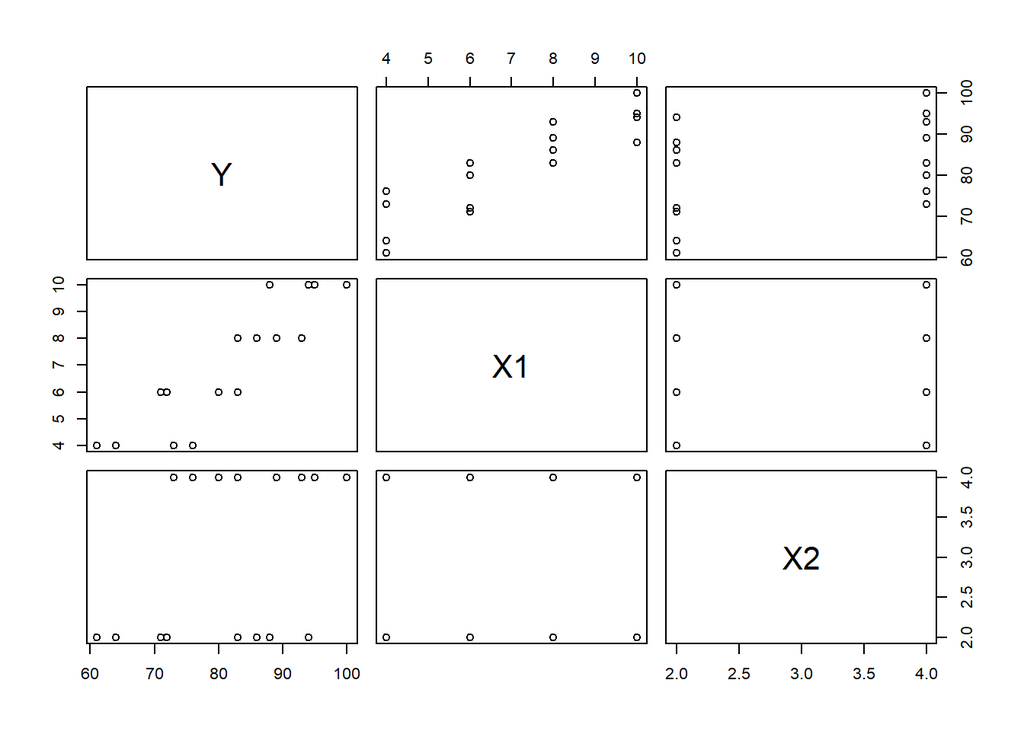

```r
Data3=read.table("AS33Data.txt", header = FALSE, sep = "")
Y = Data3$V1
X1= Data3$V2
X2=Data3$V3


pairs(~Y+X1+X2)
```

```r
colnames(Data3)=c("Y","X1","X2")
cor(Data3)
```

```
##            Y        X1        X2
## Y  1.0000000 0.8923929 0.3945807
## X1 0.8923929 1.0000000 0.0000000
## X2 0.3945807 0.0000000 1.0000000
```

3.b)The regression model is Y= 37.65 + 4.425X1 + 4.375X2. Holding the other variable constant, Increasing one unit of X1 leads to an increase in the brand liking by 4.425, and holding X1 constant, an one unit increase in X2 leads to an increase of the brand by 4.375.

```r
Lmodel=lm(Y~X1+X2)
summary(Lmodel)
```

```
##
## Call:
## lm(formula = Y ~ X1 + X2)
##
## Residuals:
##    Min     1Q Median     3Q    Max
## -4.400 -1.762  0.025  1.587  4.200
##
## Coefficients:
##             Estimate Std. Error t value Pr(>|t|)
## (Intercept)  37.6500     2.9961  12.566 1.20e-08 ***
## X1            4.4250     0.3011  14.695 1.78e-09 ***
## X2            4.3750     0.6733   6.498 2.01e-05 ***
## ---
## Signif. codes:  0 '***' 0.001 '**' 0.01 '*' 0.05 '.' 0.1 ' ' 1
##
## Residual standard error: 2.693 on 13 degrees of freedom
## Multiple R-squared:  0.9521, Adjusted R-squared:  0.9447
## F-statistic: 129.1 on 2 and 13 DF,  p-value: 2.658e-09
```

```r
#Y=37.65+4.25X1+4.375X2
```

3.c)

There are no outliers in the residuals and errors are normally distributed.

```r
Lmodel$residual
```

```
##     1     2     3     4     5     6     7     8     9    10    11    12    13
## -0.10  0.15 -3.10  3.15 -0.95 -1.70 -1.95  1.30  1.20 -1.55  4.20  2.45 -2.65
##    14    15    16
## -4.40  3.35  0.60
```

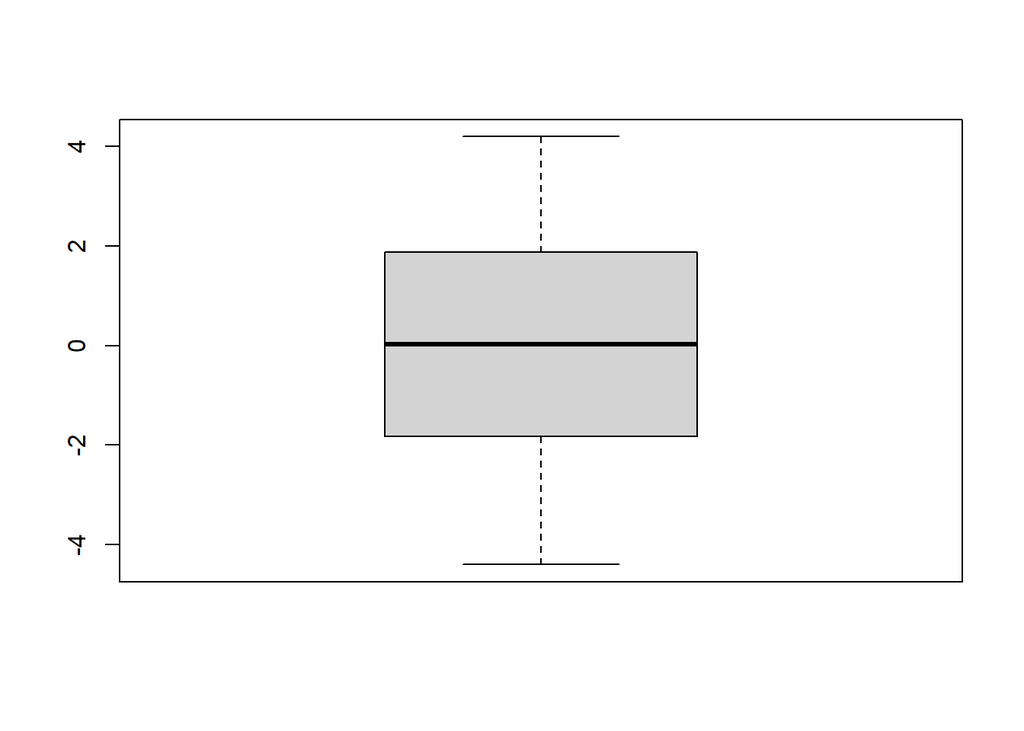

```r
boxplot(Lmodel$residual)
```

3.d)

Based on the plots, we observe that residuals are random and almost normally distributed with mean 0.

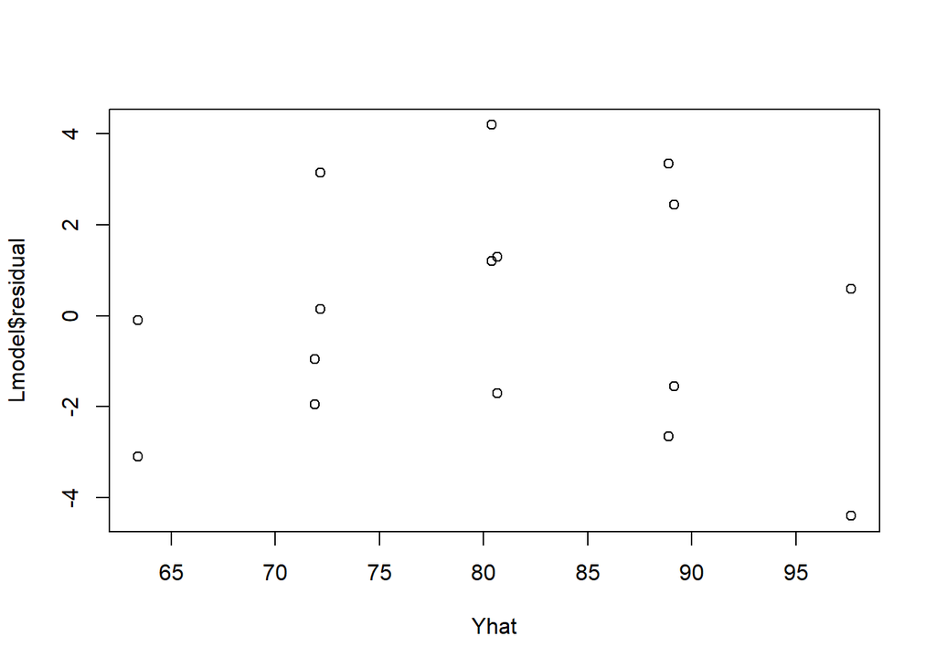

```r
Yhat=37.65+4.25*X1+4.375*X2

plot(Yhat,Lmodel$residual)
```

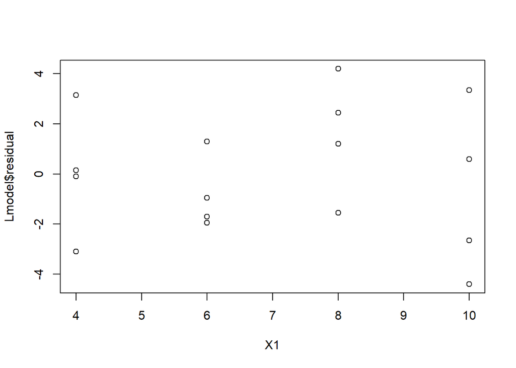

```r
plot(X1,Lmodel$residual)
```

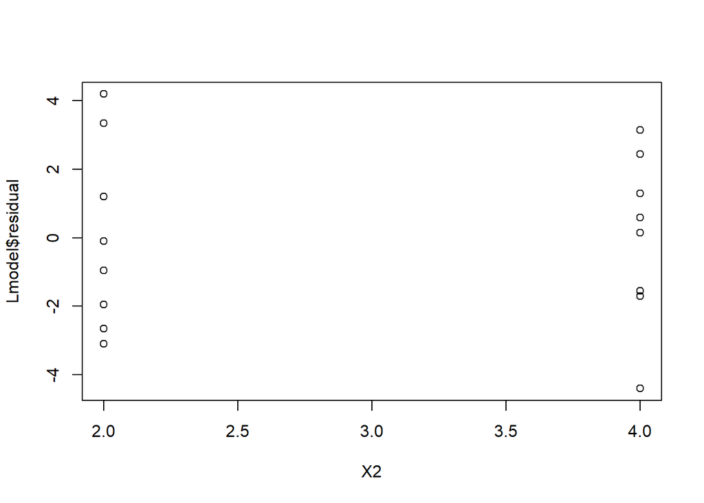

```r
plot(X2,Lmodel$residual)
```

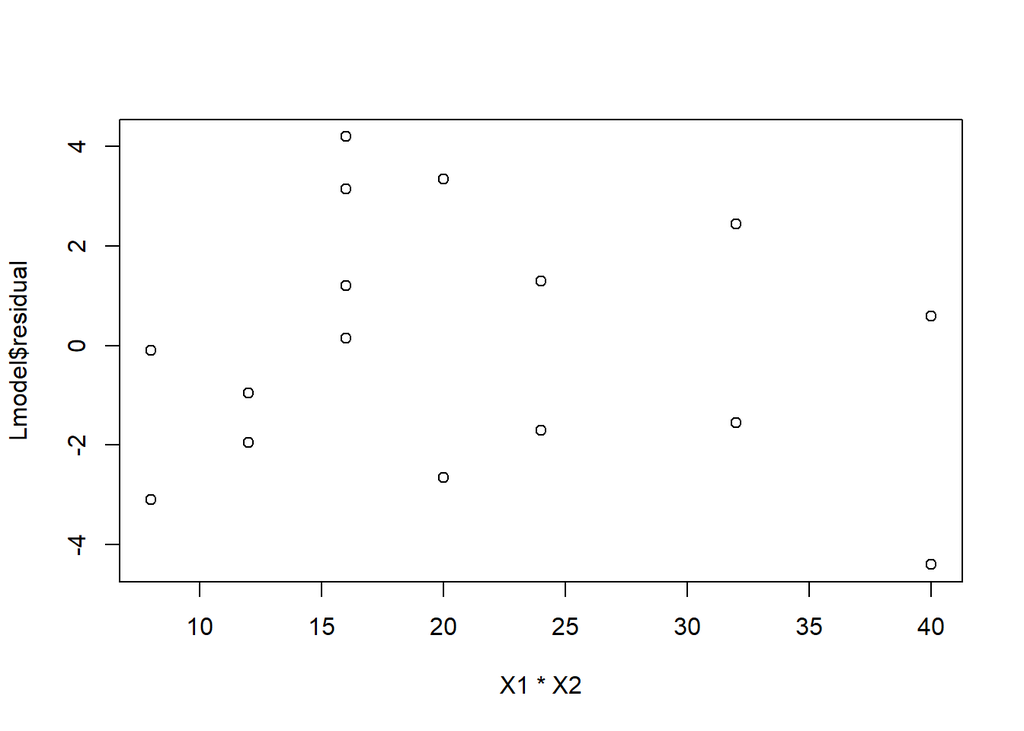

```r
plot(X1*X2,Lmodel$residual)
```

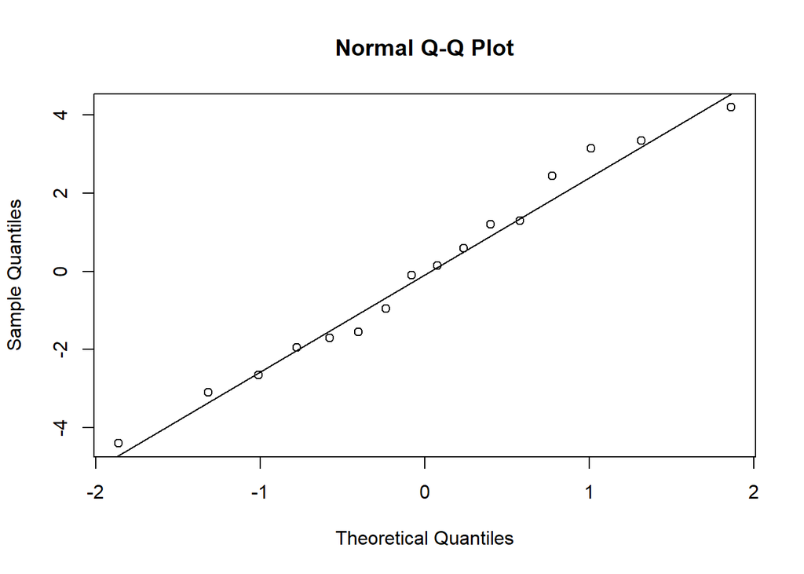

```r
qqnorm(Lmodel$residual)
qqline(Lmodel$residual)
```

3.e)

Ho: Error variance is constant Ha: Error variance is not constant

```r
library(lmtest)
Lmodel2=lm(log((Lmodel$residuals)^2)~X1+X2)
bptest(Lmodel2)
```

```
##
##  studentized Breusch-Pagan test
##
## data:  Lmodel2
## BP = 5.0338, df = 2, p-value = 0.08071
```

3.f)

Ho: Linear Model fits the Data(Y=b0+b1X1+b2X2) Ha: There is lack of fit in the model(Y<>b0+b1X1+b2X2)

```r
#Lmodel=lm(Y~X1+X2)

anova(Lmodel2,Lmodel)
```

```
## Analysis of Variance Table
##
## Response: log((Lmodel$residuals)^2)
##           Df Sum Sq Mean Sq F value Pr(>F)
## X1         1 14.058 14.0580  3.1016 0.1017
## X2         1  0.202  0.2015  0.0445 0.8363
## Residuals 13 58.923  4.5325
```

Problem 4

4.a)

Stem and leaf represents the histograms of quantitative data.

```r
Data4=read.table("As34Data.txt", header = FALSE, sep = "")
Y = Data4$V1
X1 = Data4$V2
X2 = Data4$V3
X3 = Data4$V4
X4 = Data4$V5

Xmat=as.matrix(cbind(rep(1,length(Y)),X1,X2,X3,X4))
stem(X1)
```

```
##
##   The decimal point is at the |
##
##    0 | 0000000000000000
##    2 | 00000000000000000000000
##    4 | 00000
##    6 | 0
##    8 | 0
##   10 | 00
##   12 | 00000
##   14 | 0000000000000
##   16 | 0000000000
##   18 | 000
##   20 | 00
```

```r
stem(X2)
```

```
##
##   The decimal point is at the |
##
##    2 | 0
##    4 | 080003358
##    6 | 012613
##    8 | 00001223456001555689
##   10 | 013344566677778123344666668
##   12 | 00011115777889002
##   14 | 6
```

```r
stem(X3)
```

```
##
##   The decimal point is 1 digit(s) to the left of the |
##
##   0 | 0000000000000000000000000000002333333333334444445555556678889
##   1 | 023444469
##   2 | 1223477
##   3 | 3
##   4 |
##   5 | 7
##   6 | 0
##   7 | 3
```

```r
stem(X4)
```

```
##
##   The decimal point is 5 digit(s) to the right of the |
##
##   0 | 333333444444
##   0 | 555666667778899
##   1 | 000001111222333334
##   1 | 578889
##   2 | 011122334444
##   2 | 555788899
##   3 | 002
##   3 | 567
##   4 | 23
##   4 | 8
```

4.b)

From observing the correlation matrix we can see that there is no strong correlation between the predictor and response variables.

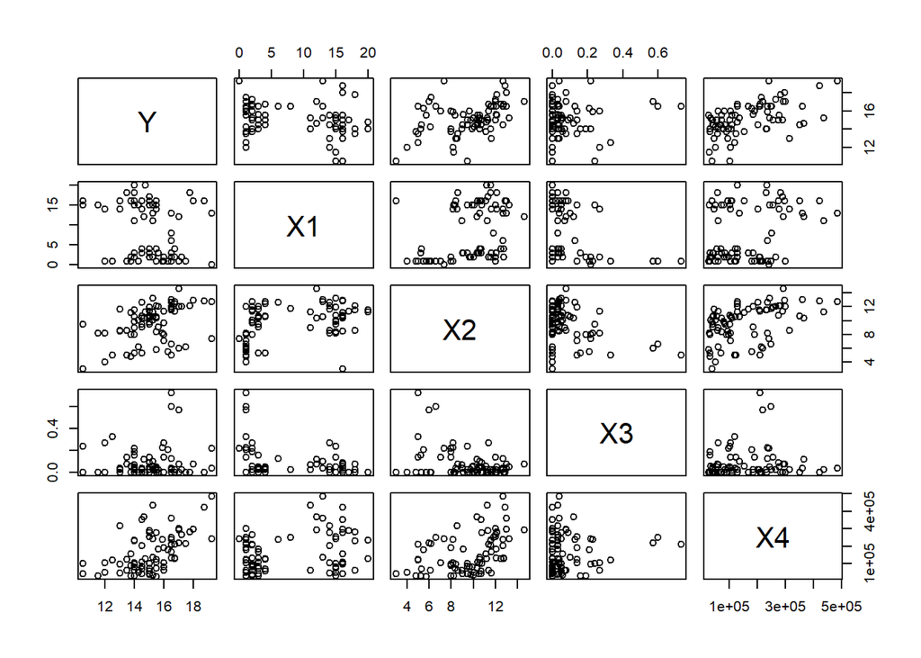

```r
pairs(~Y+X1+X2+X3+X4)
```

```r
colnames(Data4)=c("Y","X1","X2","X3","X4")
cor(Data4)
```

```
##              Y         X1         X2          X3         X4
## Y   1.00000000 -0.2502846  0.4137872  0.06652647 0.53526237
## X1 -0.25028456  1.0000000  0.3888264 -0.25266347 0.28858350
## X2  0.41378716  0.3888264  1.0000000 -0.37976174 0.44069713
## X3  0.06652647 -0.2526635 -0.3797617  1.00000000 0.08061073
## X4  0.53526237  0.2885835  0.4406971  0.08061073 1.00000000
```

4.c)

```r
Lmod=lm(Y~X1+X2+X3+X4)
Lmod
```

```
##
## Call:
## lm(formula = Y ~ X1 + X2 + X3 + X4)
##
## Coefficients:
## (Intercept)           X1           X2           X3           X4
##   1.220e+01   -1.420e-01    2.820e-01    6.193e-01    7.924e-06
```

4.d)

There are some outliers in the data and the plot is noy symmetrical and the assumption made on noise of regression is wrong.

```r
Lmod$residuals
```

```
##            1            2            3            4            5            6
## -1.035672440 -1.513806414 -0.591053402 -0.133568082  0.313283765 -3.187185224
##            7            8            9           10           11           12
## -0.538356749  0.236302386  1.989220372  0.105829603  0.023124830 -0.337070751
##           13           14           15           16           17           18
##  0.717869468 -0.392411015 -0.201019573 -0.814937024  0.101690072 -1.759131637
##           19           20           21           22           23           24
## -1.210114916 -0.634341765 -0.366004170  0.288596123 -0.093200248  0.233884284
##           25           26           27           28           29           30
## -0.853339941 -2.123934469  0.466014057 -0.573974675 -1.068826727 -0.197717691
##           31           32           33           34           35           36
## -1.121737177 -0.173906919 -1.030125636 -0.090953654  0.215053952  0.784804746
##           37           38           39           40           41           42
##  1.083920373 -2.132451269 -0.185470952 -1.120385453 -0.012771680  2.500938643
##           43           44           45           46           47           48
## -1.582833452  0.929599530  0.394236721  0.117200255  0.815339787  1.605896564
##           49           50           51           52           53           54
##  0.557941960  0.494737472  0.207611404 -0.032045798  1.155796537  0.234272601
##           55           56           57           58           59           60
## -1.073489739  1.059646672 -0.261711555  1.031651273 -0.345957207  0.203372872
##           61           62           63           64           65           66
##  0.917961126  2.944144932  2.459696482  1.859088749  1.451807658 -0.483857748
##           67           68           69           70           71           72
## -0.756250356  2.011402309  0.078550427  0.009892809  1.766898426 -0.463930876
##           73           74           75           76           77           78
## -0.510410866 -0.106354746  1.209427169 -0.261085606 -0.627547725  0.910085787
##           79           80           81
## -0.550846871 -2.030180944 -0.906819056
```

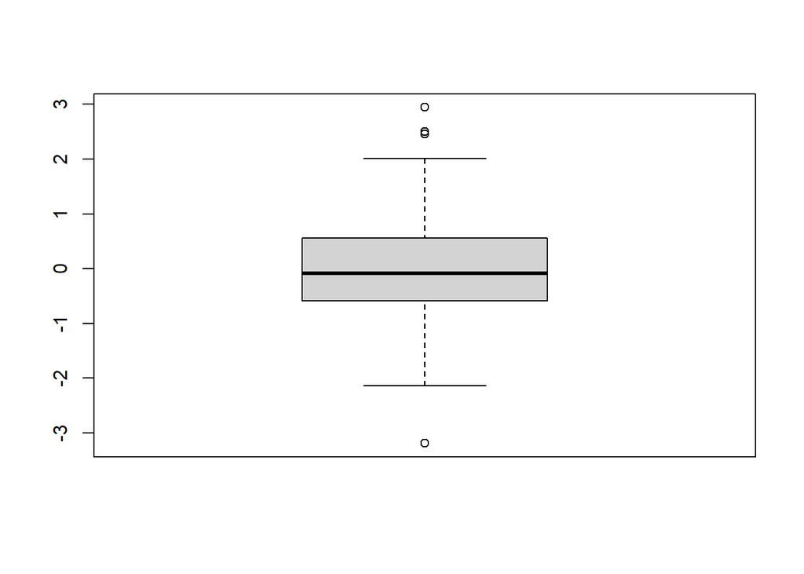

```r
boxplot(Lmod$residuals)
```

4.e)

Based on the residual plots we find that residuals are not uniform with mean 0.

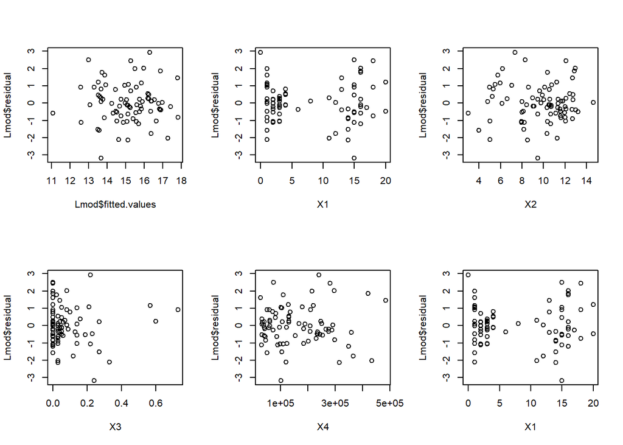

```r
par(mfrow=c(2,3))
plot(Lmod$fitted.values,Lmod$residual)
plot(X1,Lmod$residual)
plot(X2,Lmod$residual)
plot(X3,Lmod$residual)
plot(X4,Lmod$residual)

plot(X1,Lmod$residual)
```

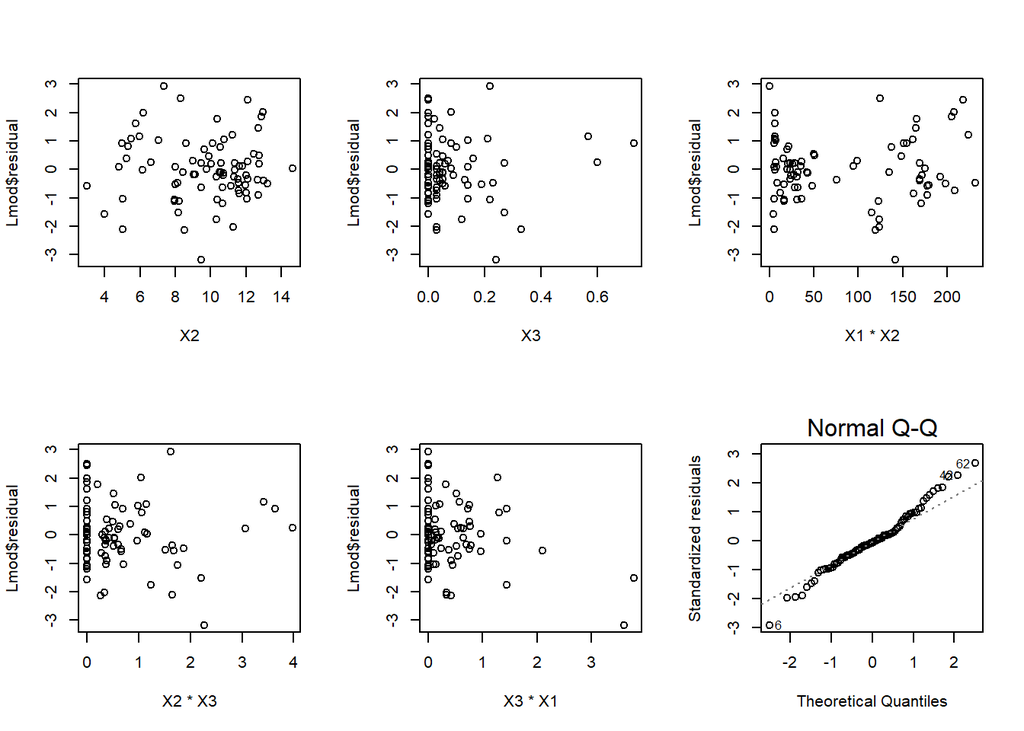

```r
plot(X2,Lmod$residual)
plot(X3,Lmod$residual)
plot(X1*X2,Lmod$residual)
plot(X2*X3,Lmod$residual)
plot(X3*X1,Lmod$residual)

plot(Lmod,which=2)
```

4.f)

The model can be Y~X1+X2+X4

```r
anova(Lmod)#Y~X1+X2+X3+X4
```

```
## Analysis of Variance Table
##
## Response: Y
##           Df Sum Sq Mean Sq F value    Pr(>F)
## X1         1 14.819  14.819 11.4649  0.001125 **
## X2         1 72.802  72.802 56.3262 9.699e-11 ***
## X3         1  8.381   8.381  6.4846  0.012904 *
## X4         1 42.325  42.325 32.7464 1.976e-07 ***
## Residuals 76 98.231   1.293
## ---
## Signif. codes:  0 '***' 0.001 '**' 0.01 '*' 0.05 '.' 0.1 ' ' 1
```

```r
Lmod2=lm(Y~X1+X2+X4)

anova(Lmod2,Lmod)
```

```
## Analysis of Variance Table
##
## Model 1: Y ~ X1 + X2 + X4
## Model 2: Y ~ X1 + X2 + X3 + X4
##   Res.Df    RSS Df Sum of Sq      F Pr(>F)
## 1     77 98.650
## 2     76 98.231  1   0.41975 0.3248 0.5704
```

4.g)

H0: Error variance is constant Ha: Error variance is not constant

```r
Yhat=sort(fitted(Lmod2))

Y1=Yhat[1:40]
Y2=Yhat[41:81]

e1=Y1-Y[1:40]
Med1=median(e1)

e2=Y2-Y[41:81]
Med2=median(e2)

n1=length(Y1)
n2=length(Y2)


d1=e1-Med1
Mean1=mean(d1)
d2=e2-Med2
Mean2=mean(d2)

s=sqrt(sum((d1-Mean1)^2)+sum((d2-Mean2)^2)/(length(Yhat)-2))

tstar=(Mean1-Mean2)/(s*sqrt((1/n1)+(1/n2)))
tstar
```

```
## [1] 0.09588115
```

```r
t=qt(0.05,df=n1+n2-2)
t
```

```
## [1] -1.664371
```

Problem 5

5.a)

H0: b1=b2=b3=b4=0 (all the coeficients are 0) Ha: At least one of the coef is not 0

Since the p value of beta tests for X1, X2 , X3 and X4 are less than 0.05 we reject null hypothesis.

```r
#Q5
anova(Lmod)
```

```
## Analysis of Variance Table
##
## Response: Y
##           Df Sum Sq Mean Sq F value    Pr(>F)
## X1         1 14.819  14.819 11.4649  0.001125 **
## X2         1 72.802  72.802 56.3262 9.699e-11 ***
## X3         1  8.381   8.381  6.4846  0.012904 *
## X4         1 42.325  42.325 32.7464 1.976e-07 ***
## Residuals 76 98.231   1.293
## ---
## Signif. codes:  0 '***' 0.001 '**' 0.01 '*' 0.05 '.' 0.1 ' ' 1
```

5.b)

The confidence intervals of betas are :

Beta1: (-0.19663959, -0.08742769) Beta2: (0.1203875, 0.4436456) Beta3: (-2.161312, 3.399999) Beta4: (4.381297e-06, 1.146731e-05)

```r
n=length(Y)
alpha=1 - 0.95
g=4
t=qt(1 - alpha/(2 * g), n - 4 - 1)
t
```

```
## [1] 2.558541
```

```r
beta1 = coef(summary(Lmod))[,1][[2]]
beta2 = coef(summary(Lmod))[,1][[3]]
beta3 = coef(summary(Lmod))[,1][[4]]
beta4 = coef(summary(Lmod))[,1][[5]]

sebeta1 = coef(summary(Lmod))[,2][[2]]
sebeta2 = coef(summary(Lmod))[,2][[3]]
sebeta3 = coef(summary(Lmod))[,2][[4]]
sebeta4 = coef(summary(Lmod))[,2][[5]]


CIbeta1 = c(beta1 - t * sebeta1, beta1 + t * sebeta1)
CIbeta2 = c(beta2 - t * sebeta2, beta2 + t * sebeta2)
CIbeta3 = c(beta3 - t * sebeta3, beta3 + t * sebeta3)
CIbeta4 = c(beta4 - t * sebeta4, beta4 + t * sebeta4)


CIbeta1
```

```
## [1] -0.19663959 -0.08742769
```

```r
CIbeta2
```

```
## [1] 0.1203875 0.4436456
```

```r
CIbeta3
```

```
## [1] -2.161312  3.399999
```

```r
CIbeta4
```

```
## [1] 4.381297e-06 1.146731e-05
```

5.c)

The value of Rsquare is 0.58 the variation of model explains 58% variation in Y wrt X.

```r
sse = sum((fitted(Lmod) - Y)^2)

sst=sum((Y-mean(Y))^2)

Rsquare=1-(sse/sst)
Rsquare
```

```
## [1] 0.5847496
```

Problem 6

The family of estimates of coeficients is

```r
#Q6

Data42=read.table("As36.txt", header = FALSE, sep = "")
n=nrow(Data42)
Xh1=t(cbind(rep(1,n),t(Data42$V1)))
Xh2=t(cbind(rep(1,n),t(Data42$V2)))
Xh3=t(cbind(rep(1,n),t(Data42$V3)))
Xh4=t(cbind(rep(1,n),t(Data42$V4)))
beta0=coef(summary(Lmod))[,1][[2]]

Bmat=cbind(beta0,beta1,beta2,beta3,beta4)
Bmat=as.matrix(Bmat)

Yhat1=Bmat%*%Xh1;
Yhat2=Bmat%*%Xh2;
Yhat3=Bmat%*%Xh3;
Yhat4=Bmat%*%Xh4;

sse = sum((fitted(Lmod) - Y)^2)

Sigmasquare=sse/n-2

measure1=(Sigmasquare*t(Xh1)%*%solve(t(Xmat)%*%Xmat)%*%Xh1)^0.5

measure2=(Sigmasquare*t(Xh2)%*%solve(t(Xmat)%*%Xmat)%*%Xh2)^0.5

measure3=(Sigmasquare*t(Xh3)%*%solve(t(Xmat)%*%Xmat)%*%Xh3)^0.5

measure4=(Sigmasquare*t(Xh4)%*%solve(t(Xmat)%*%Xmat)%*%Xh4)^0.5

W = sqrt(2 * qf(p = 0.95, df1 = 5, df2 = length(Y) - 5))


conf1up=Yhat1+W*measure1
conf1lo=Yhat1-W*measure1
conf2up=Yhat2+W*measure2
conf2lo=Yhat2-W*measure2
conf3up=Yhat3+W*measure3
conf3lo=Yhat3-W*measure3
conf4lo=Yhat3+W*measure3
conf4up=Yhat3-W*measure3
c(conf1up,conf1lo)
```

```
## [1]  145.7784 -126.7568
```

```r
c(conf2up,conf2lo)
```

```
## [1]  120.6433 -104.2315
```

```r
c(conf3up,conf3lo)
```

```
## [1]  4.627043 -4.645127
```

```r
c(conf4up,conf4lo)
```

```
## [1] -4.645127  4.627043
```

Problem 7

7.a)

Transforming the data and fitting the model

```r
Ycor  = sqrt(1/(length(Y)-1))*((Y-mean(Y))/sd(Y))
X1cor = sqrt(1/(length(X1)-1))*((X1-mean(X1))/sd(X1))
X2cor = sqrt(1/(length(X2)-1))*((X2-mean(X2))/sd(X2))
X3cor = sqrt(1/(length(X3)-1))*((X3-mean(X3))/sd(X3))
X4cor = sqrt(1/(length(X4)-1))*((X4-mean(X4))/sd(X4))

Lmodel=lm(Ycor~-1+X1cor+X2cor+X3cor+X4cor)
Lmodel
```

```
##
## Call:
## lm(formula = Ycor ~ -1 + X1cor + X2cor + X3cor + X4cor)
##
## Coefficients:
##    X1cor     X2cor     X3cor     X4cor
## -0.54785   0.42365   0.04846   0.50276
```

```r
Lmod#Y~X1+X2+X3+X4
```

```
##
## Call:
## lm(formula = Y ~ X1 + X2 + X3 + X4)
##
## Coefficients:
## (Intercept)           X1           X2           X3           X4
##   1.220e+01   -1.420e-01    2.820e-01    6.193e-01    7.924e-06
```

7.b)

The Standardization coef beta hat after transformation becomes :

Betahat2=Sy/Sk*beta2hatstar

```r
Betahat2=(sd(Y)/sd(X2))*0.423#value of beta from Lmodel
Betahat2
```

```
## [1] 0.2815859
```

7.c)

The Standardization coef beta hat after transformatio becomes :

Betahatk=Sy/Sk*betakhatstar

```r
Betahat1=(sd(Y)/sd(X1))*-0.547
Betahat2=(sd(Y)/sd(X2))*0.423
Betahat3=(sd(Y)/sd(X3))*0.048
Betahat4=(sd(Y)/sd(X4))*0.502

Betahat1
```

```
## [1] -0.1418126
```

```r
Betahat2
```

```
## [1] 0.2815859
```

```r
Betahat3
```

```
## [1] 0.6134472
```

```r
Betahat4
```

```
## [1] 7.912368e-06
```

Problem 8

8.a)

The regression model is Y=50.775 + 4.425X1

```r
Y = Data3$Y
X1= Data3$X1
X2=Data3$X2

Linearmod=lm(Y~X1)
Linearmod
```

```
##
## Call:
## lm(formula = Y ~ X1)
##
## Coefficients:
## (Intercept)           X1
##      50.775        4.425
```

8.b)

We have observed that the coefficient of moisture in model 6.5b is equal to that of the moisture coefficient in this model

```r
lm(Y~X1+X2)#model in 6.5b
```

```
##
## Call:
## lm(formula = Y ~ X1 + X2)
##
## Coefficients:
## (Intercept)           X1           X2
##      37.650        4.425        4.375
```

8.c)

From anova of the models SSR(X1|X2) = SSR(X1)

```r
anova(Linearmod)
```

```
## Analysis of Variance Table
##
## Response: Y
##           Df  Sum Sq Mean Sq F value    Pr(>F)
## X1         1 1566.45 1566.45  54.751 3.356e-06 ***
## Residuals 14  400.55   28.61
## ---
## Signif. codes:  0 '***' 0.001 '**' 0.01 '*' 0.05 '.' 0.1 ' ' 1
```

```r
anova(lm(Y~X1+X2))
```

```
## Analysis of Variance Table
##
## Response: Y
##           Df  Sum Sq Mean Sq F value    Pr(>F)
## X1         1 1566.45 1566.45 215.947 1.778e-09 ***
## X2         1  306.25  306.25  42.219 2.011e-05 ***
## Residuals 13   94.30    7.25
## ---
## Signif. codes:  0 '***' 0.001 '**' 0.01 '*' 0.05 '.' 0.1 ' ' 1
```

```r
#SSR X1/X2= = SSR(X1, X2) − SSR(X2)
Ssrx1_x2=1566.45+306.25-306.25
Ssrx1_x2
```

```
## [1] 1566.45
```

8.d)

Based on (b) and (c), and also the correlation matrix in Problem 6.5(a) confirms that there is a strong linear relationship between response variable and moisture content X1.

Problem 9

9.a)

By plotting the graph the relation did not appear the same for both the populations.

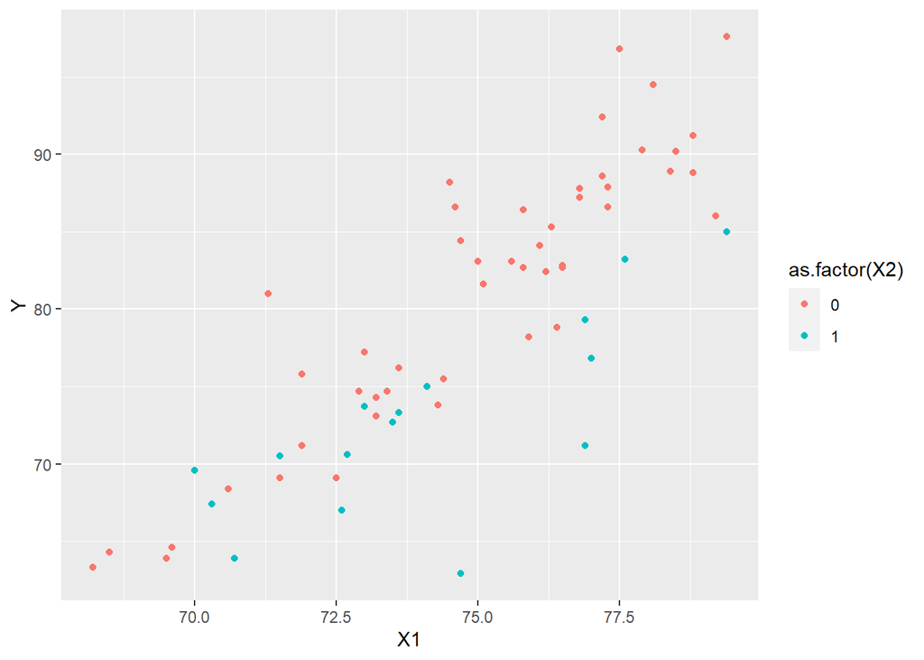

```r
Data9=read.table("AS39Data.txt", header = FALSE, sep = "")
Y = Data9$V1
X1 = Data9$V2
X2=Data9$V3

library(ggplot2)
ggplot(Data9, aes(X1, Y, colour = as.factor(X2))) + geom_point()
```

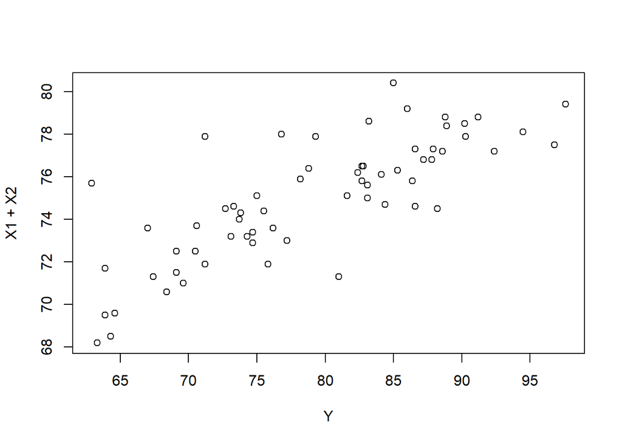

```r
plot(Y,X1+X2)
```

9.b)

H0:All the coeficients are zero Ha : At least one of the coefficient is not zero

```r
fit = lm(Y~X1+X2+X1*X2)
fit
```

```
##
## Call:
## lm(formula = Y ~ X1 + X2 + X1 * X2)
##
## Coefficients:
## (Intercept)           X1           X2        X1:X2
##    -126.905        2.776       76.022       -1.107
```

```r
summary(fit)
```

```
##
## Call:
## lm(formula = Y ~ X1 + X2 + X1 * X2)
##
## Residuals:
##      Min       1Q   Median       3Q      Max
## -10.8470  -2.1639   0.0913   1.9348   9.9836
##
## Coefficients:
##              Estimate Std. Error t value Pr(>|t|)
## (Intercept) -126.9052    14.7225  -8.620 4.33e-12 ***
## X1             2.7759     0.1963  14.142  < 2e-16 ***
## X2            76.0215    30.1314   2.523  0.01430 *
## X1:X2         -1.1075     0.4055  -2.731  0.00828 **
## ---
## Signif. codes:  0 '***' 0.001 '**' 0.01 '*' 0.05 '.' 0.1 ' ' 1
##
## Residual standard error: 3.893 on 60 degrees of freedom
## Multiple R-squared:  0.8233, Adjusted R-squared:  0.8145
## F-statistic: 93.21 on 3 and 60 DF,  p-value: < 2.2e-16
```

```r
fit$coef
```

```
## (Intercept)          X1          X2       X1:X2
## -126.905171    2.775898   76.021532   -1.107482
```

```r
anova(fit)
```

```
## Analysis of Variance Table
##
## Response: Y
##           Df Sum Sq Mean Sq  F value    Pr(>F)
## X1         1 3670.9  3670.9 242.2760 < 2.2e-16 ***
## X2         1  453.1   453.1  29.9073 9.282e-07 ***
## X1:X2      1  113.0   113.0   7.4578  0.008281 **
## Residuals 60  909.1    15.2
## ---
## Signif. codes:  0 '***' 0.001 '**' 0.01 '*' 0.05 '.' 0.1 ' ' 1
```

```r
fit = lm(Y~X1)
anova(fit)
```

```
## Analysis of Variance Table
##
## Response: Y
##           Df Sum Sq Mean Sq F value    Pr(>F)
## X1         1 3670.9  3670.9  154.28 < 2.2e-16 ***
## Residuals 62 1475.3    23.8
## ---
## Signif. codes:  0 '***' 0.001 '**' 0.01 '*' 0.05 '.' 0.1 ' ' 1
```

```r
fit1 = update(fit,.~.+X2+X1*X2)
anova(fit1)
```

```
## Analysis of Variance Table
##
## Response: Y
##           Df Sum Sq Mean Sq  F value    Pr(>F)
## X1         1 3670.9  3670.9 242.2760 < 2.2e-16 ***
## X2         1  453.1   453.1  29.9073 9.282e-07 ***
## X1:X2      1  113.0   113.0   7.4578  0.008281 **
## Residuals 60  909.1    15.2
## ---
## Signif. codes:  0 '***' 0.001 '**' 0.01 '*' 0.05 '.' 0.1 ' ' 1
```

```r
nrow(Data)
```

```
## [1] 10
```

```r
#From anova table

#SSR(X_2, X_1X_2|X_1) = SSR(X_2, X_1X_2, X_1) - SSR(X_1)
#=3670.9 + 453.1 + 113.0 - 3670.9

SSR=3670.9 + 453.1 + 113.0 - 3670.9

MSEf=909.1/60

DofF=3
DofP=1

Fstar=(SSR/(DofF-DofP))/(909.1/60)
Fstar
```

```
## [1] 18.68111
```

```r
qf(0.95,2,60)
```

```
## [1] 3.150411
```

9.c)

```r
Y11=Y[X2==1]
Y12=Y[X2==0]
X11=X1[X2==1]
X10=X1[X2==0]

LinMod1=lm(Y11~X11)
LinMod2=lm(Y12~X10)

LinMod1
```

```
##
## Call:
## lm(formula = Y11 ~ X11)
##
## Coefficients:
## (Intercept)          X11
##     -50.884        1.668
```

```r
#Y=-50.884+1.668X
LinMod2
```

```
##
## Call:
## lm(formula = Y12 ~ X10)
##
## Coefficients:
## (Intercept)          X10
##    -126.905        2.776
```

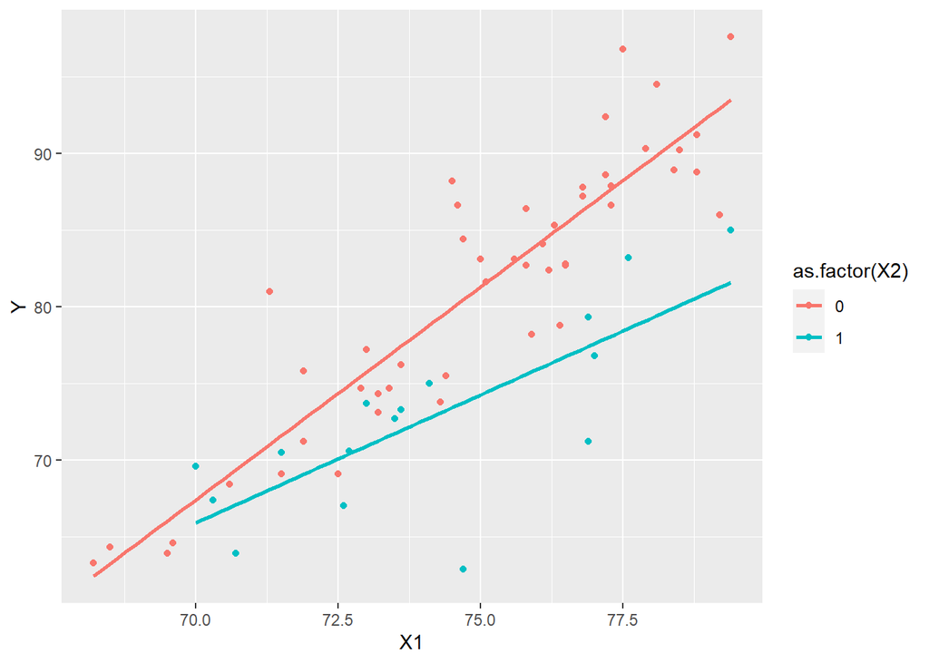

```r
#Y=-126.905+2.776X

#Difference in the Model
#Y=76.021+1.102X

ggplot(Data9, aes(x=X1, y=Y, col=as.factor(X2))) + geom_point() +
            geom_smooth(method="lm", se=FALSE)
```